# Practical Machine Learning Assignment

Alyssa Goldberg

January 29, 2016

# Introduction

In addition to finding the most accurate model, we’ll also keep track of processing time for each model because the most accurate model may not be the “best” model for real-life large data sets.

# Data Cleanup and Pre-processing

We are interested in the accelerometer data as it relates to whether an exercise was performed correctly. Visual inspection of the data shows us that we can remove columns that contain 1 through 7, which contain identifying data, time stamp and other data irrelevant to our question.

Many columns contain no data. If more than 80% of the data in a column is NA, eliminate that data from the column set.

```
## [1] 19622    53
```

Next,remove columns with near zero variance or zero variance

There are now 53 columns left, which is identical to what it was previously, so we can leave out the costly nearZeroVar()function in the future. What is left contains data that can be used to classify whether an exercise was performed correctly, class A or incorrectly, classes B through E.

# Modeling and Training Data

## Subset Training Data

As this is a classification problem, we’ll be using a variety of “tree” models, including: **rpart**, **randomForest** and **gbm**.

## Model 1, rpart()

Create first model fit using recursive partitioning and regression trees, a.k.a **rpart** and predict on that model. **rpart** is great for creating a decision tree plot (see Appendix fig 1) and is more scalable, but tends to have lower accuracy compared to other functions.

Below is the accuracy and confusion matrix:

```
##  Accuracy
## 0.7188465
```

|  | A | B | C | D | E |
| --- | --- | --- | --- | --- | --- |
| A | 466 | 49 | 5 | 7 | 4 |
| B | 11 | 220 | 33 | 12 | 25 |
| C | 14 | 24 | 229 | 43 | 44 |
| D | 50 | 73 | 64 | 246 | 49 |
| E | 11 | 10 | 8 | 10 | 235 |

## Model 2, randomForest()

`randomForest` differs from rpart in that it creates several subsets of trees, a forest rather than a single tree, and then averages them together to find the best model. It can be less scalable re: CPU, but if processing time is not an issue, generally produces the best results.

```r
ptm<-proc.time()
set.seed(3383)


model.fit<-randomForest(classe ~ ., data=strain, importance = TRUE, allowParallel=TRUE) #being sneaky here and producing our final training model after discovering that this is the best model fit.

predict<-predict(model.fit, stest1)
cmp2<-confusionMatrix(predict, stest1$classe)

t<-cmp2$table
trainall.time<-proc.time()-ptm
```

predict on the second model

```
##       Accuracy          Kappa  AccuracyLower  AccuracyUpper   AccuracyNull
##      0.9788877      0.9732862      0.9714669      0.9848079      0.2842430
## AccuracyPValue  McnemarPValue
##      0.0000000            NaN
```

```r
cmp2$overall["Accuracy"]
```

Accuracy 0.9788877

```r
kable(t2)
```

|  | A | B | C | D | E |
| --- | --- | --- | --- | --- | --- |
| A | 549 | 7 | 0 | 1 | 0 |
| B | 1 | 365 | 11 | 0 | 0 |
| C | 0 | 4 | 327 | 10 | 2 |
| D | 0 | 0 | 1 | 307 | 2 |
| E | 2 | 0 | 0 | 0 | 353 |

## Model 3, train() method=gbm

`randomForest` gave us a pretty good Accuracy, we’ll see if we can do better with boosting using the method **gbm* (for classification boosting) in the `train` function.

```
## Stochastic Gradient Boosting
##
## 4537 samples
##   52 predictor
##    5 classes: 'A', 'B', 'C', 'D', 'E'
##
## No pre-processing
## Resampling: Cross-Validated (5 fold, repeated 1 times)
## Summary of sample sizes: 3629, 3629, 3629, 3631, 3630
## Resampling results across tuning parameters:
##
##   interaction.depth  n.trees  Accuracy   Kappa      Accuracy SD
##   1                   50      0.7562297  0.6907052  0.014001115
##   1                  100      0.8249983  0.7783593  0.013139273
##   1                  150      0.8510022  0.8113774  0.012936625
##   2                   50      0.8446087  0.8031443  0.010778871
##   2                  100      0.9014762  0.8752628  0.007972290
##   2                  150      0.9219713  0.9012586  0.012290797
##   3                   50      0.8902355  0.8610216  0.012405872
##   3                  100      0.9325532  0.9146411  0.006508225
##   3                  150      0.9446755  0.9300113  0.005098588
##   Kappa SD
##   0.017692966
##   0.016482413
##   0.016348686
##   0.013682292
##   0.010065436
##   0.015590197
##   0.015684179
##   0.008276051
##   0.006467697
##
## Tuning parameter 'shrinkage' was held constant at a value of 0.1
##
## Tuning parameter 'n.minobsinnode' was held constant at a value of 10
## Accuracy was used to select the optimal model using  the largest value.
## The final values used for the model were n.trees = 150,
##  interaction.depth = 3, shrinkage = 0.1 and n.minobsinnode = 10.
```

predict on third model

Accuracy 0.9588054

|  | A | B | C | D | E |
| --- | --- | --- | --- | --- | --- |
| A | 542 | 9 | 1 | 0 | 0 |
| B | 4 | 357 | 18 | 1 | 3 |
| C | 2 | 9 | 316 | 9 | 6 |
| D | 0 | 0 | 3 | 306 | 7 |
| E | 4 | 1 | 1 | 2 | 341 |

## Compare all 3 Models for Accuracy and Compare Processing Times

| model | Accuracy | user.self | sys.self | elapsed |
| --- | --- | --- | --- | --- |
| rpart | 0.7188465 | 1.20 | 0.00 | 1.20 |
| gradient boosting | 0.9588054 | 108.05 | 0.14 | 108.32 |
| random forest | 0.9788877 | 24.61 | 0.12 | 24.77 |

Applying Model 2 to our large training set vs. testing set we get the following predictions:

# Final Prediction for Quiz

```r
print(finalPrediction[1:20])
```

```
##  1  2  3  4  5  6  7  8  9 10 11 12 13 14 15 16 17 18 19 20
##  B  A  B  A  A  E  D  B  A  A  B  C  B  A  E  E  A  B  B  B
## Levels: A B C D E
```

# Appendix

fig 1. Recursive Partitioning (rpart)Tree Plot & Prediction Plot Model 1

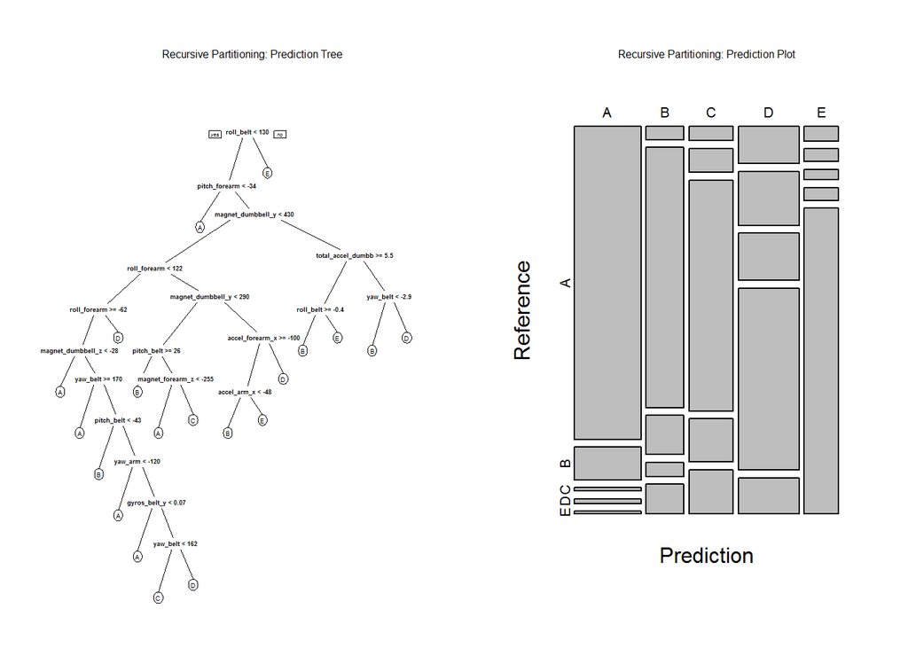

fig 2. Random Forest (randomForest) Error Plot & Prediction Plot Model 2

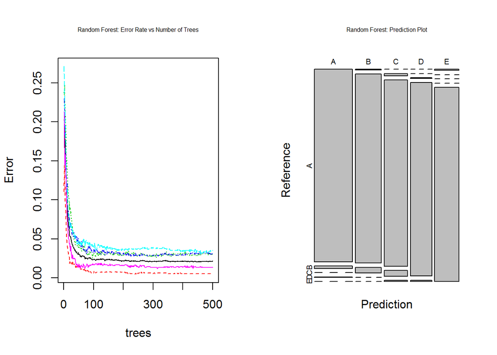

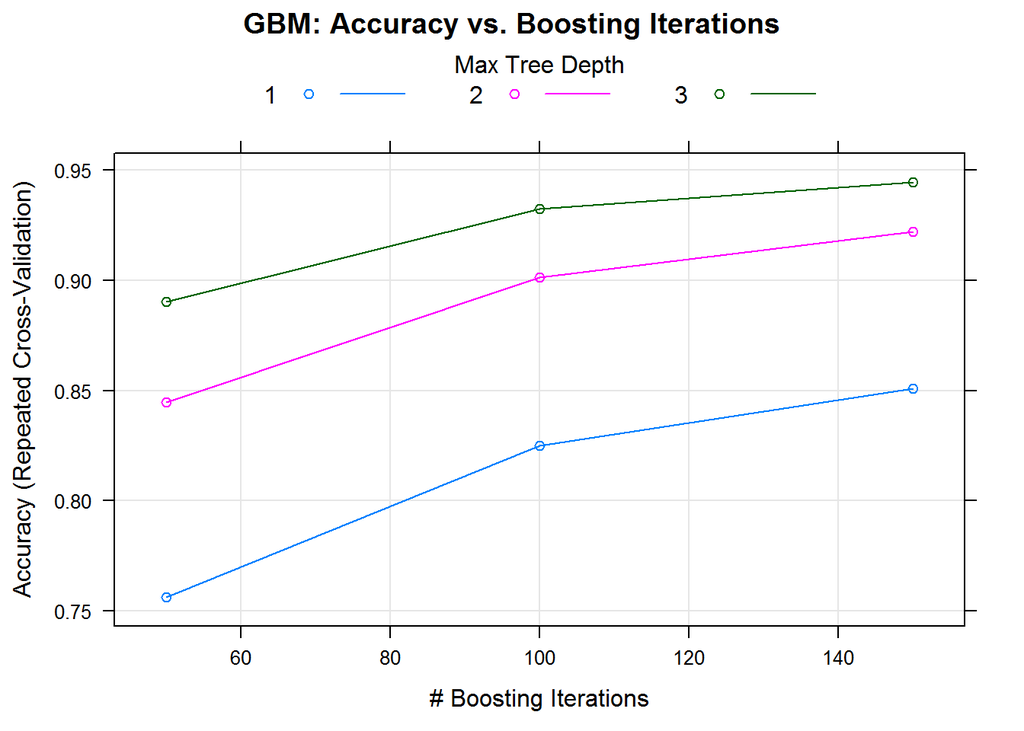

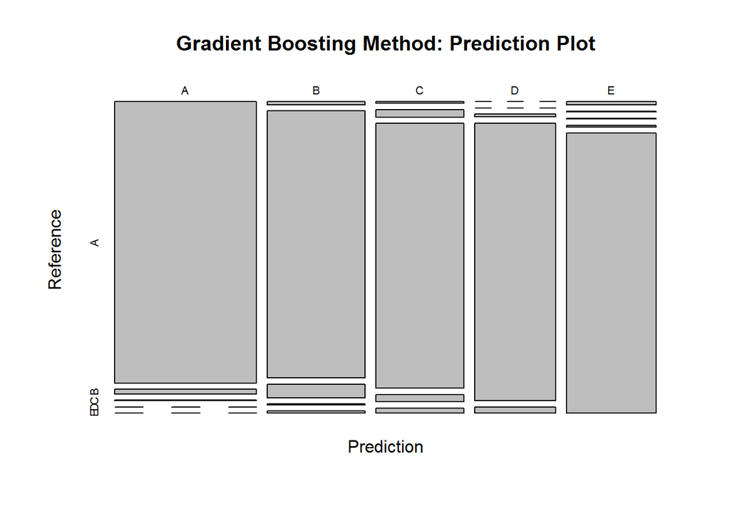

fig 4. Model 2 Random Forest Variable Importance

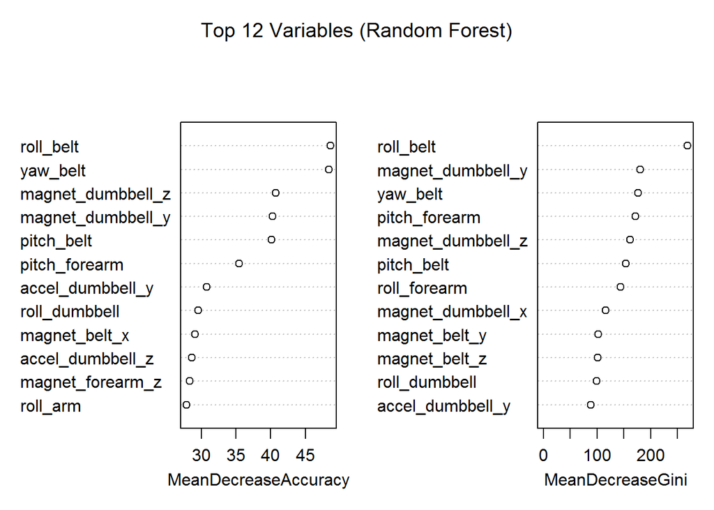

## Source:

Velloso, E.; Bulling, A.; Gellersen, H.; Ugulino, W.; Fuks, H. Qualitative Activity Recognition of Weight Lifting Exercises. Proceedings of 4th International Conference in Cooperation with SIGCHI (Augmented Human ’13) . Stuttgart, Germany: ACM SIGCHI, 2013.